# R Notebook

# el valor del lift 0.40/0.256 = 1.56.

# - ?Es razonable la regla anterior? Clasificar las reglas en: accionables/triviales/inexplicables

#———————————————————————————–

#_______________________________________________________ # Paso 4: Mejorar la performance del modelo #_______________________________________________________

```r
# Mostrar las 5 reglas con mayor lift
inspect(sort(groceryrules, by = "lift")[1:5])
```

|  | lhs |  | rhs | support | confidence | lift | count |
| --- | --- | --- | --- | --- | --- | --- | --- |
| [1] | {herbs} | => | {root vegetables} | 0.007015760 | 0.4312500 | 3.956477 | 69 |
| [2] | {berries} | => | {whipped/sour cream} | 0.009049314 | 0.2721713 | 3.796886 | 89 |
| [3] | {other vegetables,tropical fruit,whole milk} | => | {root vegetables} | 0.007015760 | 0.4107143 | 3.768074 | 69 |
| [4] | {beef,other vegetables} | => | {root vegetables} | 0.007930859 | 0.4020619 | 3.688692 | 78 |
| [5] | {other vegetables,tropical fruit} | => | {pip fruit} | 0.009456024 | 0.2634561 | 3.482649 | 93 |

```r
NA
```

#———————————————————————————- # Interpretaciones : # ——————————————————————————— # - La primera regla, con un lift de aprox. 3.96, implica que las personas que compran hierbas son # casi cuatro veces m?s propensos a comprar hortalizas que el cliente t?pico # (?alg?n tipo de guiso?) #  
# - La regla n?mero dos es tambi?n interesante. Crema batida es m?s de tres veces m?s probable # de ser encontrada en una canasta de compras con bayas en comparaci?n con otras canastas. # (?alg?n tipo de postre?) #———————————————————————————–

```r
inspect(sort(groceryrules, by = "confidence")[1:5])
```

|  | lhs |  | rhs | support | confidence | lift | count |
| --- | --- | --- | --- | --- | --- | --- | --- |
| [1] | {butter,whipped/sour cream} | => | {whole milk} | 0.006710727 | 0.6600000 | 2.583008 | 66 |
| [2] | {butter,yogurt} | => | {whole milk} | 0.009354347 | 0.6388889 | 2.500387 | 92 |
| [3] | {butter,root vegetables} | => | {whole milk} | 0.008235892 | 0.6377953 | 2.496107 | 81 |
| [4] | {curd,tropical fruit} | => | {whole milk} | 0.006507372 | 0.6336634 | 2.479936 | 64 |
| [5] | {butter,tropical fruit} | => | {whole milk} | 0.006202339 | 0.6224490 | 2.436047 | 61 |

```r
NA
```

# Otra opcion es enfocarse en una regla

```r
# Subconjuntos de reglas
berryrules <- subset(groceryrules, items %in% "berries")
inspect(berryrules)
```

|  | lhs |  | rhs | support | confidence | lift | count |
| --- | --- | --- | --- | --- | --- | --- | --- |
| [1] | {berries} | => | {whipped/sour cream} | 0.009049314 | 0.2721713 | 3.796886 | 89 |
| [2] | {berries} | => | {yogurt} | 0.010574479 | 0.3180428 | 2.279848 | 104 |
| [3] | {berries} | => | {other vegetables} | 0.010269446 | 0.3088685 | 1.596280 | 101 |
| [4] | {berries} | => | {whole milk} | 0.011794611 | 0.3547401 | 1.388328 | 116 |

#———————————————————————————- # Uso de subset() : # ——————————————————————————— # - La palabra clave items empareja un item que aparezca en alguna regla. Es posible delimitar # que esta ocurra solo a la izquierda o derecha usando lhs y rhs.

```
lhs --> busqueda a la izquerda
```

# - El operador %in% significa que al menos uno de los items debe ser encontrado, de la lista de

# items definidos. Si se desea encontrar reglas con berries y yogurt,deber?a escribirse

# %in%c(“berries”, “yogurt”).

# - Existen otros operadores disponibles para emparejamiento parcial (%pin%) y emparejamiento

# completo (%ain%). Emparejamiento parcial permite encontrar ambos: citrus fruit y tropical fruit

# en una sola busqueda: items %pin% “fruit”. Emparejamiento completo requiere que todos los items

# listados est?n presentes. Por ejemplo, items %ain% c(“berries”, “yogurt”) encuentra solo las

# reglas con yogurt y berries al mismo tiempo.

# - Los subconjuntos tambien pueden ser imitados por soporte, confianza o lift. Por ejemplo,

# confidence > 0.50.

# - Los criterios de emparejamiento pueden ser combinados con operadores de R estandar y logicos como

# y (&), o (|), y negacion (!).

#———————————————————————————–

# Revisar: https://www.jstatsoft.org/article/view/v014i15/v14i15.pdf

```r
measures <- interestMeasure(x = groceryrules, measure = c("coverage", "fishersExactTest"),
                            transactions = groceries)
summary(measures)
```

```
    coverage        fishersExactTest
 Min.   :0.009964   Min.   :0.0000000
 1st Qu.:0.018709   1st Qu.:0.0000000
 Median :0.024809   Median :0.0000000
 Mean   :0.032608   Mean   :0.0057786
 3rd Qu.:0.035892   3rd Qu.:0.0000001
 Max.   :0.255516   Max.   :0.5608331
```

```r
  # Exportar las reglas obtenidas
write(groceryrules, file = "groceryrules.csv",
    sep = ",", quote = TRUE, row.names = FALSE)
```

```r
# Convertir reglas en dataframe
groceryrules_df <- as(groceryrules, "data.frame")
head(groceryrules_df)
```

|  | rules | support | confidence | lift | count |
| --- | --- | --- | --- | --- | --- |
| 1 | {pot plants} => {whole milk} | 0.006914082 | 0.4000000 | 1.565460 | 68 |
| 2 | {pasta} => {whole milk} | 0.006100661 | 0.4054054 | 1.586614 | 60 |
| 3 | {herbs} => {root vegetables} | 0.007015760 | 0.4312500 | 3.956477 | 69 |
| 4 | {herbs} => {other vegetables} | 0.007727504 | 0.4750000 | 2.454874 | 76 |
| 5 | {herbs} => {whole milk} | 0.007727504 | 0.4750000 | 1.858983 | 76 |
| 6 | {processed cheese} => {whole milk} | 0.007015760 | 0.4233129 | 1.656698 | 69 |

# Realizaqr el analisis solo con clientes que hayan comprado mas de un producto

```r
groceries_use <- groceries[basketSizes > 1]
groceryrules2 <- apriori(groceries_use, parameter = list(support =0.006,
                                                    confidence = 0.25, minlen = 2))
```

```
Apriori

Parameter specification:
```

|  | confidence | minval | smax | arem | aval | originalSupport | maxtime | support | minlen | maxlen | target | ext |
| --- | --- | --- | --- | --- | --- | --- | --- | --- | --- | --- | --- | --- |
|  | 0.25 | 0.1 | 1 | none | FALSE | TRUE | 5 | 0.006 | 2 | 10 | rules | FALSE |

```
Algorithmic control:
```

|  | filter | tree | heap | memopt | load | sort | verbose |
| --- | --- | --- | --- | --- | --- | --- | --- |
|  | 0.1 | TRUE | TRUE | FALSE | TRUE | 2 | TRUE |

```
Absolute minimum support count: 46

set item appearances ...[0 item(s)] done [0.00s].
set transactions ...[169 item(s), 7676 transaction(s)] done [0.01s].
sorting and recoding items ... [119 item(s)] done [0.00s].
creating transaction tree ... done [0.01s].
checking subsets of size 1 2 3 4 5 done [0.01s].
writing ... [767 rule(s)] done [0.00s].
creating S4 object  ... done [0.00s].
```

```r
groceryrules2
```

```
set of 767 rules
```

Tengo 767 reglas

Reduzco la cantidad de reglas

```r
# Visualizaci?n
rules <- apriori(groceries, parameter =
                   list(supp = 0.01, conf = 0.5, target = "rules"))
```

```
Apriori

Parameter specification:
```

|  | confidence | minval | smax | arem | aval | originalSupport | maxtime | support | minlen | maxlen | target | ext |
| --- | --- | --- | --- | --- | --- | --- | --- | --- | --- | --- | --- | --- |
|  | 0.5 | 0.1 | 1 | none | FALSE | TRUE | 5 | 0.01 | 1 | 10 | rules | FALSE |

```
Algorithmic control:
```

|  | filter | tree | heap | memopt | load | sort | verbose |
| --- | --- | --- | --- | --- | --- | --- | --- |
|  | 0.1 | TRUE | TRUE | FALSE | TRUE | 2 | TRUE |

```
Absolute minimum support count: 98

set item appearances ...[0 item(s)] done [0.00s].
set transactions ...[169 item(s), 9835 transaction(s)] done [0.01s].
sorting and recoding items ... [88 item(s)] done [0.00s].
creating transaction tree ... done [0.01s].
checking subsets of size 1 2 3 4 done [0.01s].
writing ... [15 rule(s)] done [0.00s].
creating S4 object  ... done [0.01s].
```

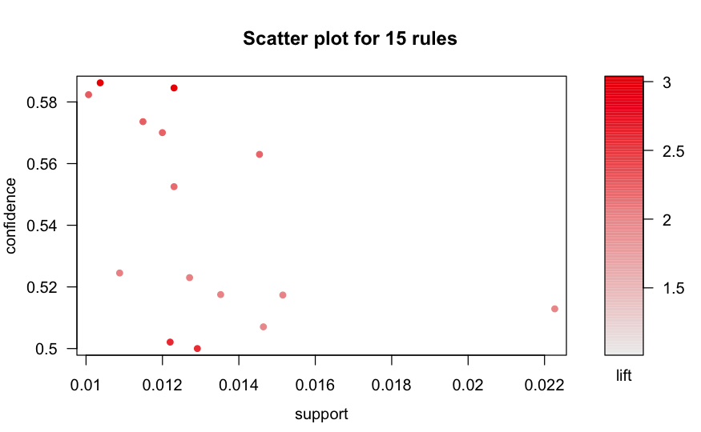

```r
library(arulesViz)
plot(rules)
```

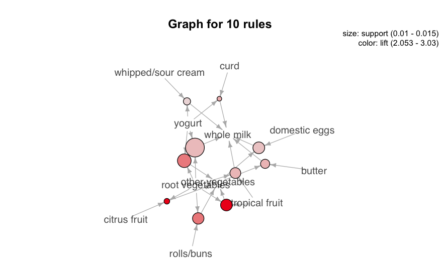

```r
subrules <- head(sort(rules, by="lift"), 10)

plot(subrules,method="graph",control=list(alpha=1))
```

```
Itemsets in Antecedent (LHS)
 [1] "{citrus fruit,root vegetables}"        "{root vegetables,tropical fruit}"
 [3] "{root vegetables,yogurt}"              "{rolls/buns,root vegetables}"
 [5] "{curd,yogurt}"                         "{butter,other vegetables}"
 [7] "{domestic eggs,other vegetables}"      "{whipped/sour cream,yogurt}"
 [9] "{other vegetables,pip fruit}"          "{tropical fruit,yogurt}"
[11] "{other vegetables,yogurt}"             "{other vegetables,whipped/sour cream}"
Itemsets in Consequent (RHS)
[1] "{whole milk}"       "{other vegetables}"
```

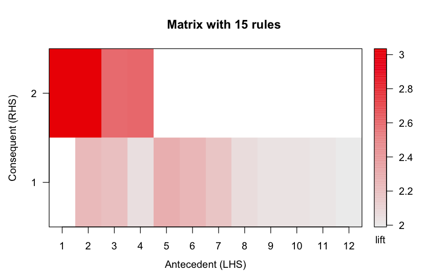

```r
plot(rules,method="matrix",measure="support")
```

El que tiene mayor intensidad, es el mayor lift

```
method 'matrix3D' is deprecated use method 'matrix' with engine '3d'
```

```
Itemsets in Antecedent (LHS)
 [1] "{citrus fruit,root vegetables}"        "{root vegetables,tropical fruit}"
 [3] "{root vegetables,yogurt}"              "{rolls/buns,root vegetables}"
 [5] "{curd,yogurt}"                         "{butter,other vegetables}"
 [7] "{domestic eggs,other vegetables}"      "{whipped/sour cream,yogurt}"
 [9] "{other vegetables,pip fruit}"          "{tropical fruit,yogurt}"
[11] "{other vegetables,yogurt}"             "{other vegetables,whipped/sour cream}"
Itemsets in Consequent (RHS)
[1] "{whole milk}"       "{other vegetables}"
```

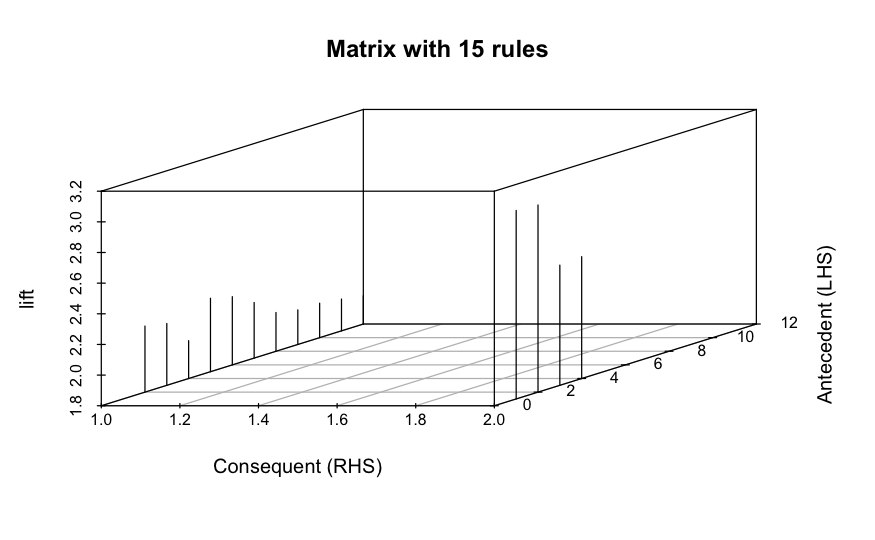

```r
plot(rules,method="matrix3D",measure="confidence")
```

# Ejemplo: BUPA

```r
library(discretization)
load("bupa.rda")
#bupa <- read.csv(file.choose())
disc.bupa=chiM(bupa)
dbupa=disc.bupa$Disc.data
```

```r
disc.bupa=chiM(bupa)
dbupa=disc.bupa$Disc.data
```

Esta datos es usado para usarlo en metodo de clasificacion

V1 .. V6 –> centrarme el V1 y V2 V7 -> Salida

```r
for (i in 1:7){dbupa[,i]=as.factor(dbupa[,i])}
dbupa<-as.data.frame(dbupa)
dbupa.ar<-as(dbupa, "transactions")
```

rules <- apriori(dbupa.ar,parameter = list(supp = 0.20, conf = 0.9,target = “rules”)) summary(rules) inspect(rules) library(arulesViz) plot(rules, measure=c(“support”, “lift”), shading=“confidence”, interactive=TRUE) plot(rules,method=“graph”,control=list(alpha=1)) plot(rules, method=“graph”, control=list(alpha=1,type=“items”))